# Data preprocessing: raw data to processed data

Marton Kovacs

2023-04-28

# Load raw data

```r
raw <- readr::read_csv(here("data/raw/ecaw_raw_data.csv"))
```

Before any exclusions we had 152 responses in the dataset.

# Excluding test data

The survey was sent out on 2022/10/10 to the participants. Thus, any responses in the dataset before that data are coming from the testing of the survey. These responses will be excluded from further analysis. We excluded 18 test responses.

```r
raw <-
  raw %>%
  dplyr::filter(lubridate::as_date(start_date) >= lubridate::as_date("2022-10-10"))
```

# Flagging not complete responses

It was optional to answer all of the questions in our survey, so it is possible to have missing responses even if the respondent finished the survey. We will keep these responses.

```r
raw <-
  raw %>%
    # dropping those questions that were open ended or conditional on other responses or irrelevant
    # flag respondents with at least one missing values from a closed-ended question
    mutate(
      has_missing = case_when(
        if_any(
          c(
            -start_date,
            -end_date,
            -status,
            -progress,
            -duration_in_seconds,
            -finished,
            -recorded_date,
            -distribution_channel,
            -user_language,
            -programming_language_other,
            -unsure_explain,
            -drawback_ecaw,
            -suggestions,
            -comments
            ),
          .fns = is.na) ~ TRUE,
        TRUE ~ FALSE
        )
      )
```

# Distribution of completition time

The median time to complete the survey was 6.1583333.

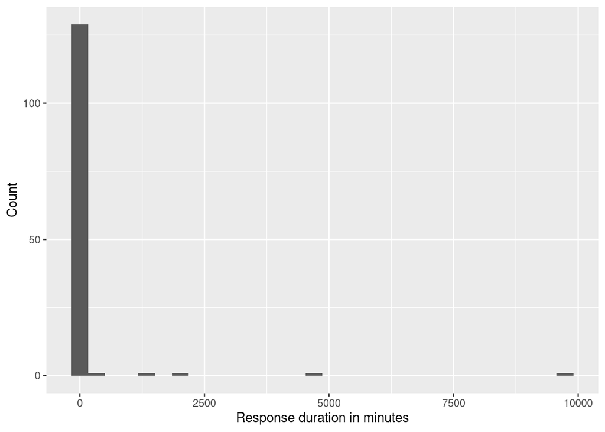

```r
# We will only need the duration in minutes for the main analysis so we calculate it here
raw <-
  raw %>%
  mutate(duration_in_mins = duration_in_seconds / 60)

raw %>%
  ggplot() +
  aes(x = duration_in_mins) +
  geom_histogram() +
  labs(
    x = "Response duration in minutes",
    y = "Count"
  )
```

# Categorizing free-text responses

In some cases respondents had the option to provide free-text responses in case they choose the *Other* option in a multiple-choice question. We will categorize these responses manually.

```r
# prepearing free-text responses for manual rating
# this part of the code is commented out not to overwrite the manual grouping
# raw %>%
#   select(response_id, programming_language_other) %>%
#   dplyr::filter(!is.na(programming_language_other)) %>%
#   mutate(group_mk = NA_character_) %>%
#   rename(programming_language_to_group = programming_language_other) %>%
#   write_xlsx(., here("data/raw/ecaw_free_text_grouping_data.xlsx"))

# processing grouped responses
raw <-
  # joining free-text responses to the data table
  left_join(
    raw,
    # reading manually grouped free-text responses
    readxl::read_xlsx(here("data/raw/ecaw_free_text_grouping_data.xlsx")),
    by = "response_id"
  ) %>%
  # replacing "Other (please describe)" text in response with grouped response
  mutate(
    programming_language  = stringr::str_replace(programming_language, "Other \\(please describe\\)", group_mk)
  ) %>%
  # drop not needed variables
  select(
    - programming_language_other,
    - programming_language_to_group,
    - group_mk)
```

# Partial responses

We only include data from participants who completed the survey in the final analysis, as preregistered (see the full text of the preregistration https://osf.io/g2fw5). There were 27 respondents who did not complete the survey.

However, these responses will be included in a supplementary analysis that will be reproted in Supplementary Material D. So we save them separately before exclusion.

```r
processed_all <-
  raw %>%
  # Delete not used variables
  select(
    - start_date,
    - end_date,
    - status,
    - progress,
    - finished,
    - duration_in_seconds,
    - recorded_date,
    - distribution_channel,
    - user_language
  ) %>%
  # Remove participants who only opened the survey but did not answer any questions. All participants who had NA for the first question (typically_trustworthy), had NAs for all questions
  # These respondents are included from the main analysis as well see section Excluding partial responses
  filter(!is.na(typically_trustworthy))

readr::write_csv(processed_all, here("data/processed/ecaw_processed_all_data.csv"))
```

The full dataset that we are going to use to calculate the results in Supplement D includes 123 responses.

We create a simple codebook for this dataset.

```r
# We re using the codebook for the source dataset as a template and append it with the new variables and their description
processed_all_codebook <-
  read_csv(here("data/source/ecaw_221102_source_codebook.csv")) %>%
  select(-original_var_name) %>%
  rename(var_name = new_var_name) %>%
  filter(var_name %in% colnames(processed_all))
# Adding new column descriptions
new_rows <- tibble(
  description = c(
    "True if respondent has any missing responses.",
    "Time spent from opening the survey to closing it in minutes."
    ),
  var_name = c(
    "has_missing",
    "duration_in_mins"
    )
)

codebook <- bind_rows(processed_all_codebook, new_rows)

readr::write_csv(processed_all_codebook, here("data/processed/ecaw_processed_all_codebook.csv"))
```

# Excluding partial responses

Excluding the respondents who did not finish the questionnaire for the main analysis.

```r
raw <-
  raw %>%
  dplyr::filter(finished) %>%
  dplyr::filter(!(response_id %in% c("R_2ZVO2mDq0eBPYDn",
                                     "R_3qr9uw1HGF53UiJ",
                                     "R_3iQHcAwCVxBXAEd",
                                     "R_1HqrkliX8SXIZqS")
                  )
  )
# We did a brief visual inspection of the data and feel these first three respondents fit better as partially completed surveys. Although they clicked through to the end of the survey, they did no answer questions after a certain point. For example, one respondent only answered the first two quetsions and clicked through to the end of the survey in 49 seconds.
# The fourth response appears to be non-sincere. All their responses were neutral, several were skipped, and it was completed in 146 seconds. This respondent may have simply wanted to see the survey.
```

# Delete not used variables

```r
raw <-
  raw %>%
  select(
    - start_date,
    - end_date,
    - status,
    - progress,
    - finished,
    - duration_in_seconds,
    - recorded_date,
    - distribution_channel,
    - user_language
  )
```

At the end of the exclusion we had 103 responses remaining for the analysis. There were 17 respondents who had at least one missing value for a closed-ended question.

# Exploring the number of responses to open-ended questions

The survey contained 4 open-ended questions (*unsure_explain*, *drawback_ecaw*, *suggestions*, *comments*) that we analyzed qualitatively, as preregistered.

Here, we calculate the number of responses for each open ended question.

```r
raw %>%
  select(unsure_explain, drawback_ecaw, suggestions, comments) %>%
  # convert to long format
  pivot_longer(
    cols = everything(),
    names_to = "variable",
    values_to = "response",
  ) %>%
  # flag missing responses
  mutate(is_na = is.na(response)) %>%
  # count missing responses per variables
  count(variable, is_na) %>%
  # keep only complete responses
  filter(!is_na)
```

```
## # A tibble: 4 × 3
##   variable       is_na     n
##   <chr>          <lgl> <int>
## 1 comments       FALSE     5
## 2 drawback_ecaw  FALSE    41
## 3 suggestions    FALSE    19
## 4 unsure_explain FALSE    27
```

# Creating a simple codebook

For creating the codebook for the processed data we will use the codebook created for the source data.

```r
codebook <-
  read_csv(here("data/source/ecaw_221102_source_codebook.csv")) %>%
  select(-original_var_name) %>%
  rename(var_name = new_var_name) %>%
  filter(var_name %in% colnames(raw))

# Adding new column descriptions
new_rows <- tibble(
  description = c(
    "True if respondent has any missing responses.",
    "Time spent from opening the survey to closing it in minutes."
    ),
  var_name = c(
    "has_missing",
    "duration_in_mins"
    )
)

codebook <- bind_rows(codebook, new_rows)

# Save the codebook
readr::write_csv(codebook, here("data/processed/ecaw_processed_codebook.csv"))
```

# Save processed dataset

```r
readr::write_csv(raw, here("data/processed/ecaw_processed_data.csv"))
```